# Lecture 9 Notes

# Residuals versus fitted of our first regression

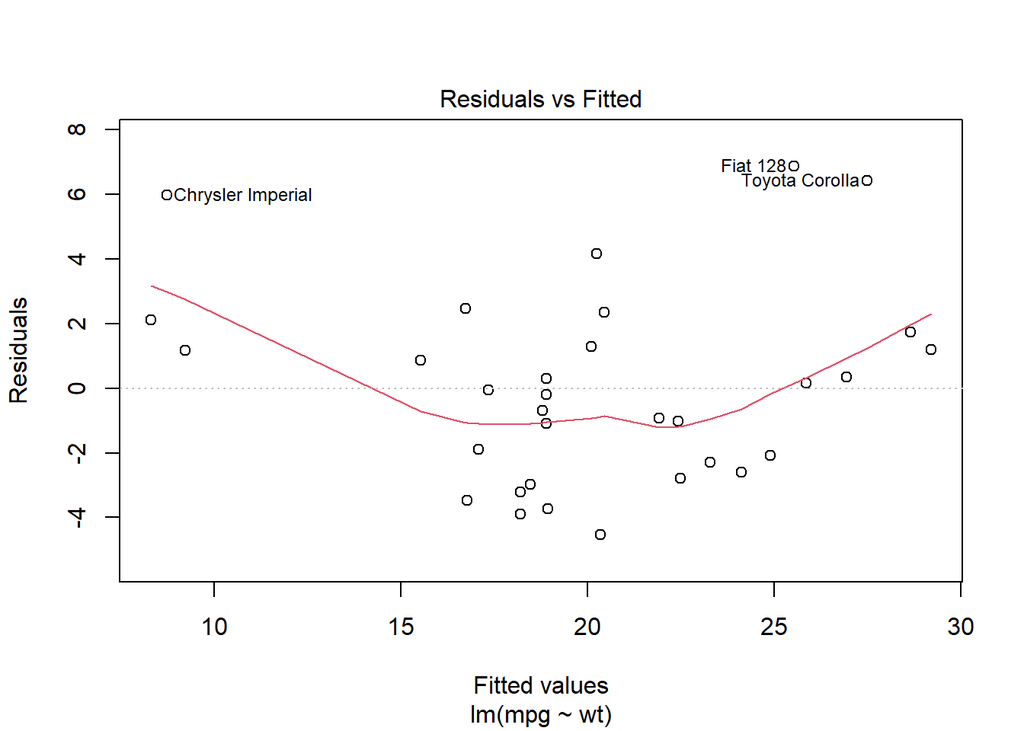

```r
mtcars %>% lm(mpg ~ wt, data=.) %>% plot(which=1)
```

# Interpretation

- This is a new way to see what we saw earlier
- The model underestimates the efficiency of the lightest and heaviest cars and overestimates the medium weight cars
- This is bad, because it means there is structure left in the residuals
- We should try to capture that structure so that all we have left in the residuals is *white noise* i.e., randomness

# Residuals versus fitted of our second regression

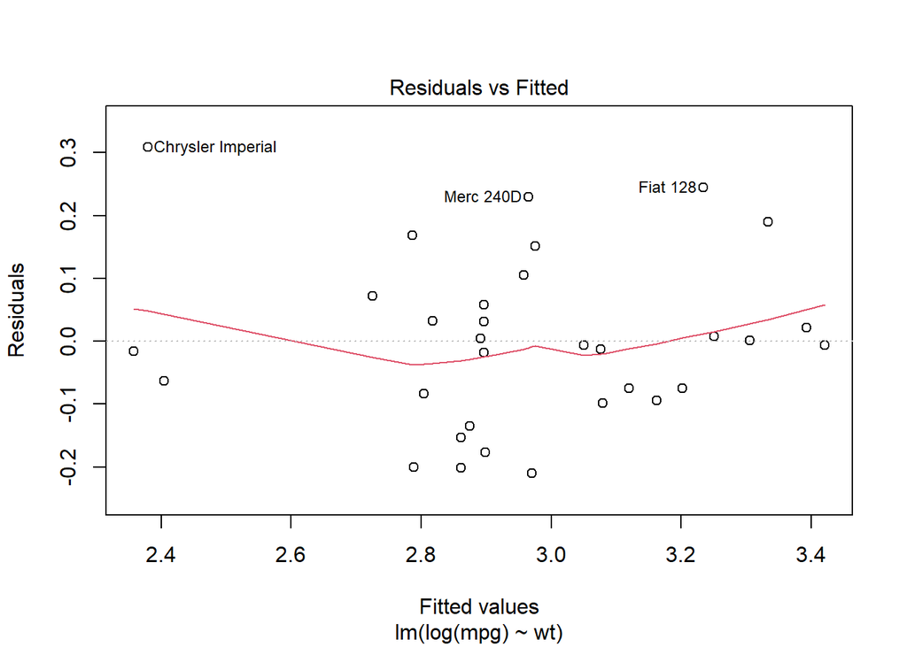

```r
mtcars %>% lm(log(mpg) ~ wt, data=.) %>% plot(which=1)
```

# Residuals versus fitted of our third regression

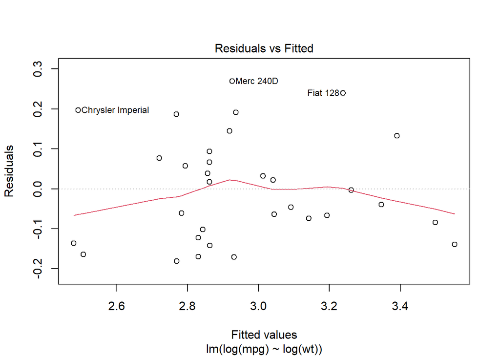

```r
mtcars %>% lm(log(mpg) ~ log(wt), data=.) %>% plot(which=1)
```

# The RESET test

- We can use the Ramsey Regression Equation Specification Error Test (RESET) to help us decide
- The test is a general specification test which can catch a variety of types of misspecification, including nonlinearity
- If our original regression is $y_i = \beta_0 + \beta_1 \cdot x_i$, we estimate something like $y_i = \beta_0 + \beta_1 \cdot x_i + \gamma_1 \cdot \hat{y}^2 + \gamma_2 \cdot \hat{y}^3$
- We then do an F-test of the $\gamma$ coefficients to see if they are statistically significant
- Rejection of the null hypothesis indicates a misspecified model
- We can use the *resettest()* function from the *lmtest* package (don’t forget to install and load it)

# RESET test of linear model

```r
mtcars %>% lm(mpg ~ wt, data=.) %>% resettest()
```

```
##
##  RESET test
##
## data:  .
## RESET = 5.1315, df1 = 2, df2 = 28, p-value = 0.01263
```

# RESET test of semi-log model

```r
mtcars %>% mutate(log_mpg = log(mpg)) %>% lm(log_mpg ~ wt, data=.) %>% resettest()
```

```
##
##  RESET test
##
## data:  .
## RESET = 1.2329, df1 = 2, df2 = 28, p-value = 0.3068
```

# RESET test of log-log model

```r
mtcars %>% mutate(log_mpg = log(mpg), log_wt = log(wt)) %>% lm(log_mpg ~ log_wt, data=.) %>% resettest()
```

```
##
##  RESET test
##
## data:  .
## RESET = 0.75605, df1 = 2, df2 = 28, p-value = 0.4789
```

# Thoughts

- In this case, it’s relatively clear that the linear model wasn’t great
- We saw this from:
  - The bivariate plot
  - The goodness of fit measures
  - The residuals versus fitted plots
  - The RESET test
- If we knew more about physics we would probably be able to explain why weight and fuel efficiency are nonlinear from a theoretical perspective

# Back to our model

- I suggested we look at the mtcars dataset because it’s a bit easier to see the nonlinear pattern there
- We can start work on our model now
- As you may have guessed it will be more complicated in our large model
- Let’s start by looking at a RESET test for our model

# The RESET test

```r
lfs %>%
  lm(HOURPAY ~ SEX + AGE + HIQUL22D + FLEX22W6 + FTPT + EMPLEN + JOBTYP + MPNR02 + MARSTA + INDE07M + NSECMJ20 + GOR9D, data=.) %>%
  resettest()
```

```
##
##  RESET test
##
## data:  .
## RESET = 123.33, df1 = 2, df2 = 7289, p-value < 2.2e-16
```

# RESET test

- Looks like bad news for our model
- There is a strong indication that we have misspecification of some sort
- Let’s have a look at the residual versus fitted plot

# Residual versus fitted

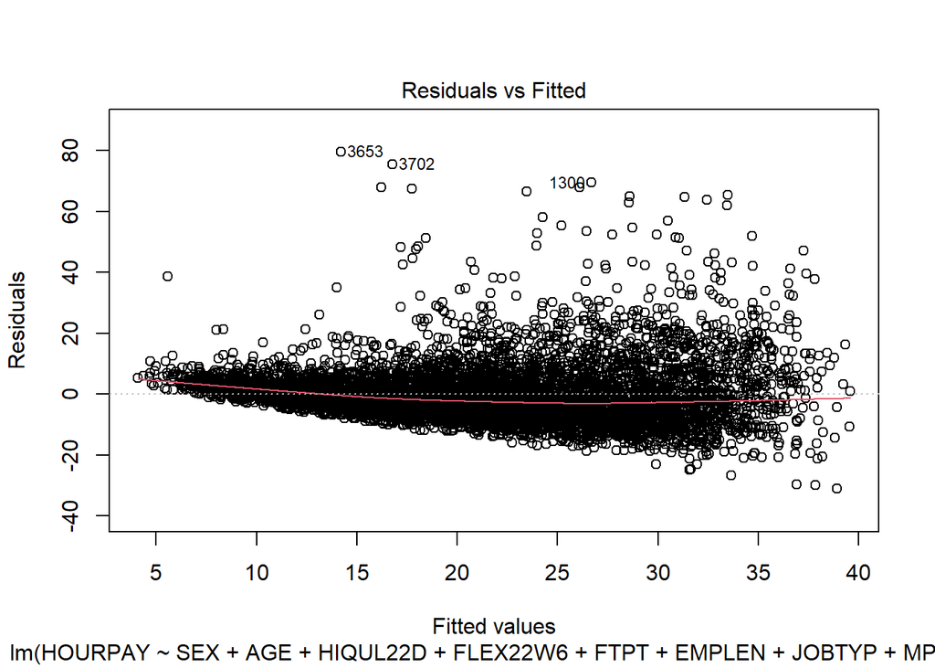

# Interpretation

- The plot looks quite different to what we had before
- The red line has a bit of a curve to it
- There are also some other patterns
- There are some high-earners where we underestimate their wage
- The points seem to be more spread out for higher fitted values
- The points becoming more spread out in this way is problematic, which leads us to Assumption 2

# Assumption 2

- We assume that the residuals have the same variance and are independent of one another
- Constant variance is referred to as homoscedasticity, the opposite being heteroscedasticity
- For the assumption to be satisfied, we should expect to see the points on our residuals versus fitted plot spread out evenly around the zero line
- Heteroscedasticity typically looks like a funnel shape
- There is a clear indication of this in our plot

# Types of heteroscedasticity

- Heteroscedasticity can appear in our models for different reasons
- The first reason might be because we have misspecified our model, so we should always check this first
- Fixing the specification might get rid of the heteroscedasticity
- Even in a correctly specified model, we may still have heteroscedasticity, sometimes referred to as *pure heteroscedasticity*
- Pure heteroscedasticity means that our standard errors are incorrect, and therefore we cannot trust our p-values / hypothesis testing
- The problem is easily fixed though

# Does our model have heteroscedasticity

- First deal check that the model is specified properly
- Ask yourself whether there are any *a priori* reasons to expect heteroscedasticity
- Are there some variables which are likely to cause heteroscedasticity?
- This process starts when we design our model and when doing our descriptive statistics and data visualisation
- There are several candidates in our model e.g., education

# Education

| HIQUL22D | Obs | Mean | Var | StdDev |
| --- | --- | --- | --- | --- |
| Degree or equivalent | 3535 | 25.02 | 159.93 | 12.65 |
| Higher education | 565 | 19.63 | 97.70 | 9.88 |
| A level or equivalent | 1604 | 17.33 | 78.49 | 8.86 |
| GCSE A*-C or equivalent | 1102 | 16.16 | 68.67 | 8.29 |
| Other qualitfication | 331 | 15.63 | 73.18 | 8.55 |
| No Qualification | 210 | 13.53 | 29.07 | 5.39 |

# Education

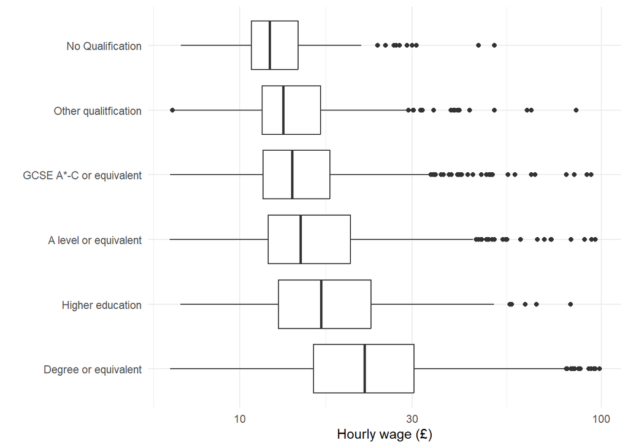

# Education

- From these basic descriptions of the data, there is already an indication that education may cause heteroscedasticity
- Before even looking a the data, we should probably have expected this
- This means that even once our model is correctly specified, we will probably still end up with heteroscedasticity

# Testing for heteroscedasticity

- While looking at plots and using our brain is important, it can also be helpful to use a formal test
- Several tests have been developed and these have various strengths and weaknesses
- We will look at the Breusch-Pagan test

# The Breusch-Pagan test

- There are some different versions of this test
- The idea is to regress an estimate of the variance of the residuals (the square of the residual) on the independent variables
- If too much of the variation in the variance is explained, then we reject the null hypothesis of homoscedasticity
- We can use the *bptest()* function from the *lmtest* package to conduct the test
- We can run it on our model now, although there isn’t much point because we have already identified an issue with the specification

# Checking our model for heteroscedasticity

```r
lfs %>%
  lm(HOURPAY ~ SEX + AGE + HIQUL22D + FLEX22W6 + FTPT + EMPLEN + JOBTYP + MPNR02 + MARSTA + INDE07M + NSECMJ20 + GOR9D,
     data=.) %>%
 bptest()
```

```
##
##  studentized Breusch-Pagan test
##
## data:  .
## BP = 390.68, df = 55, p-value < 2.2e-16
```

# Distribution of the residuals

- We assume that the variance of the residuals is constant
- Another assumption which we make is that the follow a normal distribution
- If they do not, then we cannot reliably conduct our hypothesis testing
- There are a few ways we can examine this
- While there are statistical tests of normality, I do not recommend them as they are too sensitive
- You will almost always reject a null hypothesis of a normal distribution

# Distribution of the residuals

- It is better to think about this assumption as a matter of degree
- The more normal the residuals are, the better
- We can look at a histogram of our residuals
- We can also consider a so-called QQ plot

# Histogram of residuals

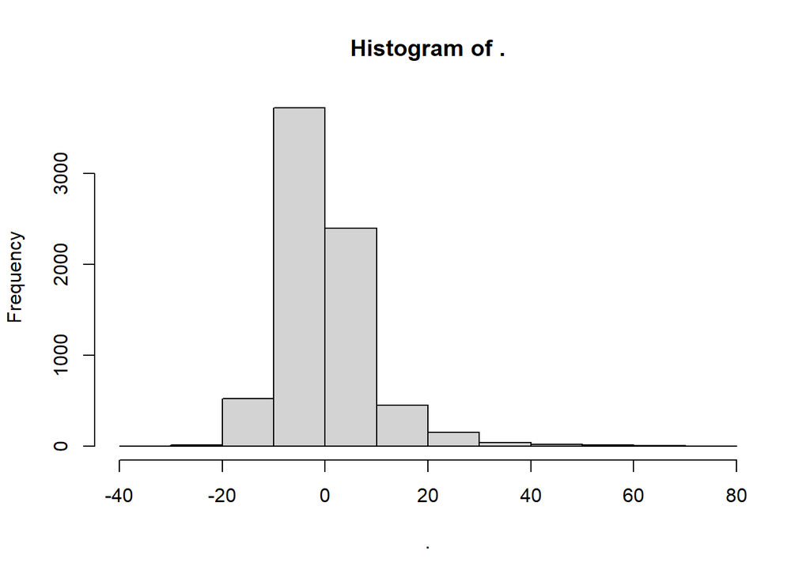

# Distribution of the residuals

- The histogram doesn’t look very normal
- It is highly skewed so we probably can’t trust our model’s p-values
- Another useful plot to look at is the quantile-quantile plot (or QQ plot)
- We are looking for the points on the chart to lie along the dotted line
- If the distribution is perfectly normal, then all the points will lie on this line

# QQ plot of residuals

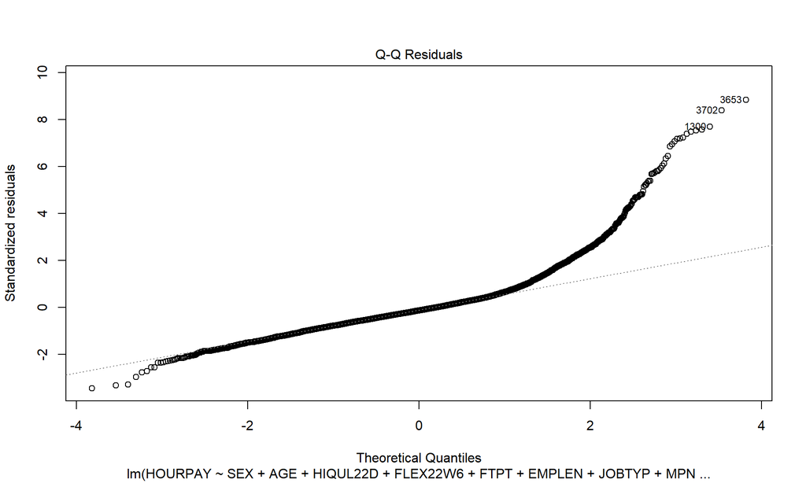

```r
lm(HOURPAY ~ SEX + AGE +  HIQUL22D + FLEX22W6 + FTPT + EMPLEN + JOBTYP + MPNR02 + MARSTA + INDE07M + NSECMJ20 + GOR9D, data=lfs) %>% plot(which=2)
```

# Distribution of the residuals

- The QQ plot is a different way of looking at the distribution
- Unsurprisingly, it shows the same problem i.e., our residuals are not normally distributed

# Problems

- So far, we have looked at aspects of assumptions 1 and 2
- We have an indication that our model is misspecified and that the residuals do not behave as desired
- It turns out, using the logarithmic transformation can help address all of these issues
- We will give it a go here

# Distributions

- Note that the assumption of normality applies to the *residuals* and not the *variables*
- However, if our dependent variable is skewed, then our residuals will probably also be skewed
- Let’s look at a histogram of our dependent variable again

# Distribution of our dependent variable

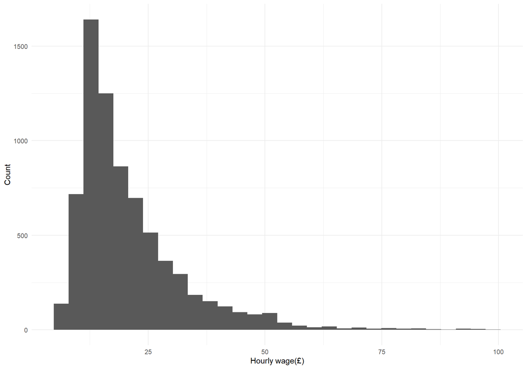

# Interpretation

- We can see our variable is skewed
- In fact, it looks skewed in a similar way to our residuals
- When you see you have a dependent variable like this, you should expect to have non-normally distributed residuals
- Using a log transformation often helps

# Distribution of log wages

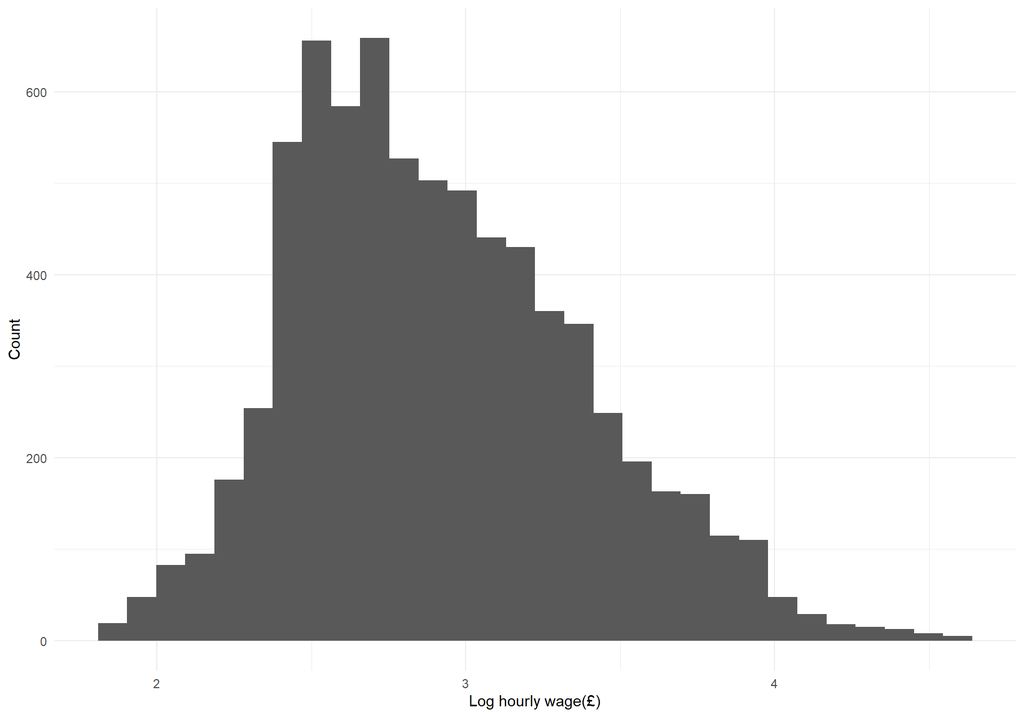

# Interpretation

- This still isn’t normal
- However, it is much closer to a normal distribution that what we started with
- We can try estimating our model in a semi-log specification and see what happens

# Dealing with zeros

- Note that this transformation only works if we have no zeros (as in our case)
- If you do, then a log transformation won’t work because the log of zero doesn’t exist
- You can consider another type of transformation, e.g., a square root transformation, but it makes interpretation of the results more difficult
- Some also suggest replacing the zero values with a small number or adding a small number to all values
- This approach is popular but may cause problems, especially if you have a large number of zeros
- Another option is to exclude the zeros and model only the positive numbers
- This limits the generalisability of the model and changes the interpretation of the results

# A semi-log regression

```r
lfs %>% mutate(log_wage = log(HOURPAY)) %>% lm(log_wage ~ SEX + AGE + HIQUL22D + FLEX22W6 + FTPT + EMPLEN + JOBTYP + MPNR02 + MARSTA + INDE07M + NSECMJ20 + GOR9D, data=.) %>% summary
```

```
##
## Call:
## lm(formula = log_wage ~ SEX + AGE + HIQUL22D + FLEX22W6 + FTPT +
##     EMPLEN + JOBTYP + MPNR02 + MARSTA + INDE07M + NSECMJ20 +
##     GOR9D, data = .)
##
## Residuals:
##      Min       1Q   Median       3Q      Max
## -1.62055 -0.21109 -0.01861  0.19648  1.96285
##
## Coefficients:
##                                                      Estimate Std. Error
## (Intercept)                                         3.0115227  0.0744636
## SEXFemale                                          -0.0719738  0.0088949
## AGE                                                 0.0041173  0.0004292
## HIQUL22DHigher education                           -0.1352929  0.0158525
## HIQUL22DA level or equivalent                      -0.1692705  0.0111238
## HIQUL22DGCSE A*-C or equivalent                    -0.2011436  0.0130428
## HIQUL22DOther qualitfication                       -0.1975554  0.0209636
## HIQUL22DNo Qualification                           -0.2873597  0.0258566
## FLEX22W6No                                          0.0567135  0.0295696
## FTPTPart-time                                      -0.0297625  0.0108578
## EMPLENThree months, less than 6                    -0.0151183  0.0321268
## EMPLEN6 months, less than 12                        0.0146695  0.0295457
## EMPLEN1 year, less than 2                           0.0065315  0.0269487
## EMPLEN2 years, less than 5                          0.0477627  0.0258684
## EMPLEN5 years, less than 10                         0.0642989  0.0264364
## EMPLEN10 years, less than 20                        0.0872838  0.0265202
## EMPLEN20 years or more                              0.1164016  0.0275700
## JOBTYPNot permanent in some way                     0.0104594  0.0236075
## MPNR0211-19                                         0.0111125  0.0175732
## MPNR0220-24                                         0.0178841  0.0228220
## MPNR02Don't know but under 25                      -0.0260251  0.0296457
## MPNR0225-49                                         0.0139941  0.0154129
## MPNR0250-249                                        0.0441019  0.0132299
## MPNR02250-499                                       0.0889228  0.0187895
## MPNR02Don't know but between 50 and 499             0.0365645  0.0219740
## MPNR02500 or more                                   0.1195901  0.0134575
## MARSTAMarried, living with spouse                   0.0579014  0.0096678
## MARSTAMarried separated from spouse                 0.0358534  0.0277121
```

[output cut: 76 more lines]

```
## GOR9DWest Midlands                                  -5.474 4.55e-08 ***
## GOR9DSouth East                                     -5.051 4.49e-07 ***
## GOR9DEast of England                                -3.778 0.000159 ***
## GOR9DEast Midlands                                  -7.915 2.85e-15 ***
## GOR9DNorth East                                     -7.434 1.17e-13 ***
## GOR9DNorth West                                     -7.203 6.49e-13 ***
## GOR9DWales                                          -7.052 1.93e-12 ***
## GOR9DNorthern Ireland                               -8.385  < 2e-16 ***
## GOR9DScotland                                       -5.719 1.11e-08 ***
## ---
## Signif. codes:  0 '***' 0.001 '**' 0.01 '*' 0.05 '.' 0.1 ' ' 1
##
## Residual standard error: 0.3402 on 7291 degrees of freedom
## Multiple R-squared:  0.483,  Adjusted R-squared:  0.4791
## F-statistic: 123.9 on 55 and 7291 DF,  p-value: < 2.2e-16
```

# Our original regression

```r
lfs %>% lm(HOURPAY ~ SEX + AGE + HIQUL22D + FLEX22W6 + FTPT + EMPLEN + JOBTYP + MPNR02 + MARSTA + INDE07M + NSECMJ20 + GOR9D, data=.) %>% summary
```

```
##
## Call:
## lm(formula = HOURPAY ~ SEX + AGE + HIQUL22D + FLEX22W6 + FTPT +
##     EMPLEN + JOBTYP + MPNR02 + MARSTA + INDE07M + NSECMJ20 +
##     GOR9D, data = .)
##
## Residuals:
##     Min      1Q  Median      3Q     Max
## -31.140  -5.101  -1.189   3.046  79.547
##
## Coefficients:
##                                                     Estimate Std. Error t value
## (Intercept)                                         25.78853    1.98215  13.010
## SEXFemale                                           -1.78189    0.23677  -7.526
## AGE                                                  0.10231    0.01142   8.956
## HIQUL22DHigher education                            -3.23076    0.42198  -7.656
## HIQUL22DA level or equivalent                       -3.85940    0.29611 -13.034
## HIQUL22DGCSE A*-C or equivalent                     -4.53640    0.34719 -13.066
## HIQUL22DOther qualitfication                        -4.44594    0.55803  -7.967
## HIQUL22DNo Qualification                            -6.14744    0.68828  -8.932
## FLEX22W6No                                           0.40302    0.78712   0.512
## FTPTPart-time                                       -0.07943    0.28902  -0.275
## EMPLENThree months, less than 6                     -0.39861    0.85519  -0.466
## EMPLEN6 months, less than 12                        -0.18981    0.78648  -0.241
## EMPLEN1 year, less than 2                           -0.30792    0.71735  -0.429
## EMPLEN2 years, less than 5                           0.34445    0.68859   0.500
## EMPLEN5 years, less than 10                          0.52264    0.70371   0.743
## EMPLEN10 years, less than 20                         1.06104    0.70594   1.503
## EMPLEN20 years or more                               1.57930    0.73389   2.152
## JOBTYPNot permanent in some way                      0.15802    0.62841   0.251
## MPNR0211-19                                          0.01830    0.46778   0.039
## MPNR0220-24                                          0.17017    0.60750   0.280
## MPNR02Don't know but under 25                       -1.01501    0.78914  -1.286
## MPNR0225-49                                          0.05431    0.41028   0.132
## MPNR0250-249                                         0.51390    0.35217   1.459
## MPNR02250-499                                        1.50815    0.50016   3.015
## MPNR02Don't know but between 50 and 499              0.65691    0.58493   1.123
## MPNR02500 or more                                    2.40393    0.35823   6.711
## MARSTAMarried, living with spouse                    1.44619    0.25735   5.620
## MARSTAMarried separated from spouse                  0.79898    0.73767   1.083
```

[output cut: 76 more lines]

```
## GOR9DWest Midlands                                 2.83e-09 ***
## GOR9DSouth East                                    2.62e-07 ***
## GOR9DEast of England                               2.99e-05 ***
## GOR9DEast Midlands                                 2.99e-14 ***
## GOR9DNorth East                                    2.19e-15 ***
## GOR9DNorth West                                    1.77e-14 ***
## GOR9DWales                                         8.65e-14 ***
## GOR9DNorthern Ireland                               < 2e-16 ***
## GOR9DScotland                                      6.57e-10 ***
## ---
## Signif. codes:  0 '***' 0.001 '**' 0.01 '*' 0.05 '.' 0.1 ' ' 1
##
## Residual standard error: 9.055 on 7291 degrees of freedom
## Multiple R-squared:  0.389,  Adjusted R-squared:  0.3844
## F-statistic: 84.41 on 55 and 7291 DF,  p-value: < 2.2e-16
```

# RESET test of our semi-log model

```r
lfs %>% mutate(log_wage = log(HOURPAY)) %>% lm(log_wage ~ SEX + AGE + HIQUL22D + FLEX22W6 + FTPT + EMPLEN + JOBTYP + MPNR02 + MARSTA + INDE07M + NSECMJ20 + GOR9D, data=.) %>% resettest()
```

```
##
##  RESET test
##
## data:  .
## RESET = 52.408, df1 = 2, df2 = 7289, p-value < 2.2e-16
```

# Residuals versus fitted plot of the semi-log model

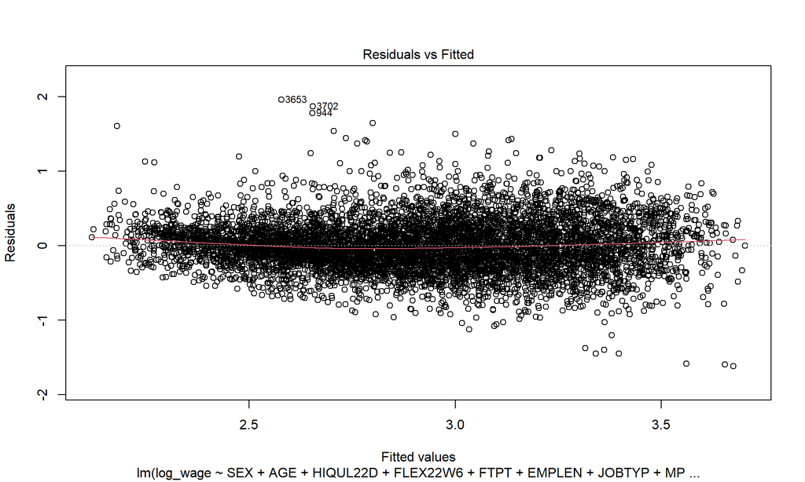

# Histogram of residuals from the semi-log model

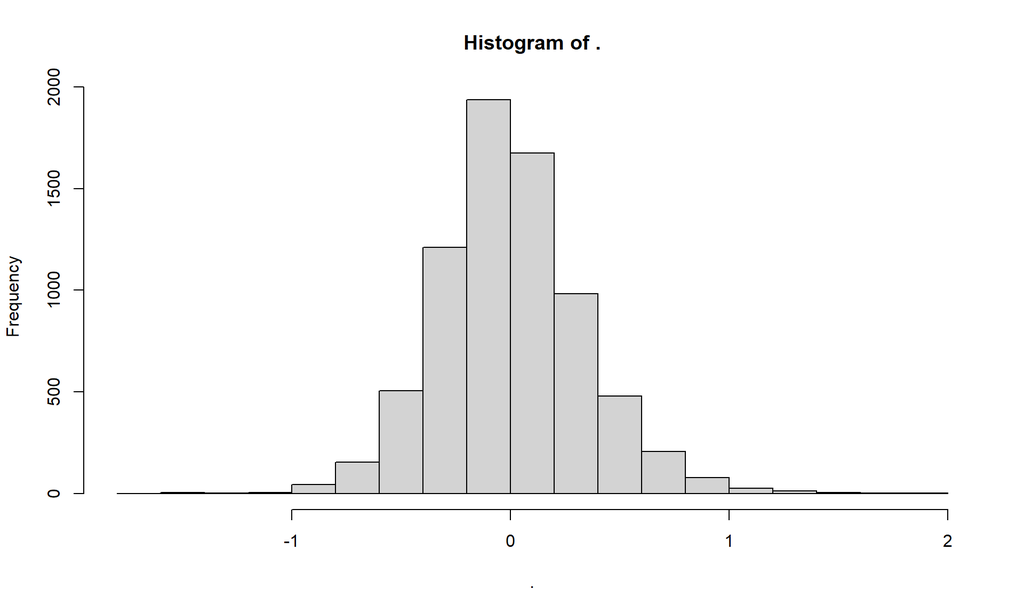

# QQ plot of the semi-log model

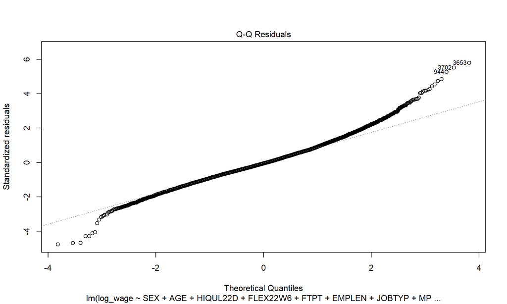

# BP test of our semi-log model

```r
lfs %>% mutate(log_wage = log(HOURPAY)) %>%
  lm(log_wage ~ SEX + AGE + HIQUL22D + FLEX22W6 + FTPT + EMPLEN + JOBTYP + MPNR02 + MARSTA + INDE07M + NSECMJ20 + GOR9D,
     data=.) %>%
  bptest()
```

```
##
##  studentized Breusch-Pagan test
##
## data:  .
## BP = 356.74, df = 55, p-value < 2.2e-16
```

# Thoughts

- Our model still isn’t passing the specification tests
- However, it is a lot better than our original model
- This is why it is important to look at both the tests and plots
- Often, we don’t get our model to a perfect state
- What we are trying to do is to get it to be as good as it can be

# Summary

- We have now covered some very important assumptions underlying our model
- We have looked at important diagnostic tools
- We have also started to see how we might fix some of the problems
- Next time, we will refine our model and discuss more of the assumptions